# Chapter 2 HW

Load packages.

```r
options(repos = list(CRAN="http://cran.rstudio.com/"))
packages <- c('caret', 'ggplot2', 'MASS', 'plyr')
install.packages(packages)
lapply(X = packages, FUN = library, character.only = TRUE)
```

```
## [[1]]
##  [1] "caret"     "lattice"   "ggplot2"   "stats"     "graphics"  "grDevices"
##  [7] "utils"     "datasets"  "methods"   "base"
##
## [[2]]
##  [1] "caret"     "lattice"   "ggplot2"   "stats"     "graphics"  "grDevices"
##  [7] "utils"     "datasets"  "methods"   "base"
##
## [[3]]
##  [1] "MASS"      "caret"     "lattice"   "ggplot2"   "stats"     "graphics"
##  [7] "grDevices" "utils"     "datasets"  "methods"   "base"
##
## [[4]]
##  [1] "plyr"      "MASS"      "caret"     "lattice"   "ggplot2"   "stats"
##  [7] "graphics"  "grDevices" "utils"     "datasets"  "methods"   "base"
```

Question 2.

```r
# loading data
prob2 <- read.csv(file = 'data/Problem2.csv')

# squaring covariates
prob2$X1.squared <- prob2$X1^2
prob2$X2.squared <- prob2$X2^2
prob2
```

```
##     Y          X1          X2   X1.squared   X2.squared
## 1   1 -0.84085548 -1.99538697 0.7070379396 3.9815691514
## 2   0  1.38435934  1.13531128 1.9164507919 1.2889317052
## 3   1 -1.25549186  0.67579457 1.5762598171 0.4566982951
## 4   0  0.07014277  0.20848326 0.0049200077 0.0434652710
## 5   1  1.71144087 -0.05784564 2.9290298608 0.0033461183
## 6   0 -0.60290798  0.89381141 0.3634980341 0.7988988440
## 7   1 -0.47216639 -0.22886538 0.2229410953 0.0523793625
## 8   1 -0.63537131 -1.96565265 0.4036967048 3.8637903390
## 9   0 -0.28577363 -0.75351045 0.0816665704 0.5677779920
## 10  1  0.13810822  1.28015162 0.0190738818 1.6387881816
## 11  1  1.22763034 -0.95290496 1.5070762611 0.9080278623
## 12  0 -0.80177945  1.62237939 0.6428502939 2.6321148949
## 13  0 -1.08039260  2.60014202 1.1672481702 6.7607385248
## 14  0 -0.15753436  0.13964851 0.0248170734 0.0195017050
```

[output cut: 86 more lines]

```r
# creating models
logistic.linear <- glm(formula = Y ~ X1 + X2, data = prob2, family = binomial)
logistic.squared <- glm(formula = Y ~ X1.squared + X2.squared, data = prob2, family = binomial)
lda.model <- lda(formula = Y ~ X1 + X2, data = prob2)
qda.model <- qda(formula = Y ~ X1 + X2, data = prob2)

# printing model objects
cat('\n', rep(x = '-', times = 20), '\n')
cat('\nlogistic.linear:\n')
```

```
##
## logistic.linear:
```

```r
cat('\n', rep(x = '-', times = 20), '\n')
logistic.linear
```

```
##
## Call:  glm(formula = Y ~ X1 + X2, family = binomial, data = prob2)
##
## Coefficients:
## (Intercept)           X1           X2
##     -0.1859       0.3725      -0.9107
##
## Degrees of Freedom: 99 Total (i.e. Null);  97 Residual
## Null Deviance:       138
## Residual Deviance: 119.9     AIC: 125.9
```

```r
cat('\n', rep(x = '-', times = 20), '\n')
cat('\nlogistic.squared:\n')
```

```
##
## logistic.squared:
```

```r
cat('\n', rep(x = '-', times = 20), '\n')
logistic.squared
```

```
##
## Call:  glm(formula = Y ~ X1.squared + X2.squared, family = binomial,
##     data = prob2)
##
## Coefficients:
## (Intercept)   X1.squared   X2.squared
##    -0.05907      0.08636     -0.16821
##
## Degrees of Freedom: 99 Total (i.e. Null);  97 Residual
## Null Deviance:       138
## Residual Deviance: 136.4     AIC: 142.4
```

```r
cat('\n', rep(x = '-', times = 20), '\n')
cat('\nlda.model:\n')
```

```
##
## lda.model:
```

```r
cat('\n', rep(x = '-', times = 20), '\n')
lda.model
```

```
## Call:
## lda(Y ~ X1 + X2, data = prob2)
##
## Prior probabilities of groups:
##    0    1
## 0.54 0.46
##
## Group means:
##            X1         X2
## 0 -0.05292198  0.3830047
## 1  0.13089757 -0.4137219
##
## Coefficients of linear discriminants:
##           LD1
## X1  0.4109256
## X2 -1.0188356
```

```r
cat('\n', rep(x = '-', times = 20), '\n')
cat('\nqda.model:\n')
```

```
##
## qda.model:
```

```r
cat('\n', rep(x = '-', times = 20), '\n')
qda.model
```

```
## Call:
## qda(Y ~ X1 + X2, data = prob2)
##
## Prior probabilities of groups:
##    0    1
## 0.54 0.46
##
## Group means:
##            X1         X2
## 0 -0.05292198  0.3830047
## 1  0.13089757 -0.4137219
```

Summaries of models.

```r
cat('\n', rep(x = '-', times = 20), '\n')
cat('\nLogistic regression with linear covariates:\n')
```

```
##
## Logistic regression with linear covariates:
```

```r
cat('\n', rep(x = '-', times = 20), '\n')
summary(object = logistic.linear)
```

```
##
## Call:
## glm(formula = Y ~ X1 + X2, family = binomial, data = prob2)
##
## Deviance Residuals:
##     Min       1Q   Median       3Q      Max
## -1.9667  -0.9771  -0.5188   1.0425   1.8100
##
## Coefficients:
##             Estimate Std. Error z value Pr(>|z|)
## (Intercept)  -0.1859     0.2204  -0.844 0.398921
## X1            0.3725     0.2438   1.528 0.126511
## X2           -0.9107     0.2462  -3.699 0.000217 ***
## ---
## Signif. codes:  0 '***' 0.001 '**' 0.01 '*' 0.05 '.' 0.1 ' ' 1
##
## (Dispersion parameter for binomial family taken to be 1)
##
##     Null deviance: 137.99  on 99  degrees of freedom
## Residual deviance: 119.91  on 97  degrees of freedom
## AIC: 125.91
##
## Number of Fisher Scoring iterations: 3
```

```r
cat('\n', rep(x = '-', times = 20), '\n')
cat('\nLogistic regression with squared covariates:\n')
```

```
##
## Logistic regression with squared covariates:
```

```r
cat('\n', rep(x = '-', times = 20), '\n')
summary(object = logistic.squared)
```

```
##
## Call:
## glm(formula = Y ~ X1.squared + X2.squared, family = binomial,
##     data = prob2)
##
## Deviance Residuals:
##     Min       1Q   Median       3Q      Max
## -1.3170  -1.1328  -0.8467   1.2035   1.4737
##
## Coefficients:
##             Estimate Std. Error z value Pr(>|z|)
## (Intercept) -0.05907    0.29926  -0.197    0.844
## X1.squared   0.08636    0.16938   0.510    0.610
## X2.squared  -0.16821    0.15196  -1.107    0.268
##
## (Dispersion parameter for binomial family taken to be 1)
##
##     Null deviance: 137.99  on 99  degrees of freedom
## Residual deviance: 136.37  on 97  degrees of freedom
## AIC: 142.37
##
## Number of Fisher Scoring iterations: 4
```

```r
cat('\n', rep(x = '-', times = 20), '\n')
cat('\nLDA:\n')
```

```
##
## LDA:
```

```r
cat('\n', rep(x = '-', times = 20), '\n')
summary(object = lda.model)
```

```
##         Length Class  Mode
## prior   2      -none- numeric
## counts  2      -none- numeric
## means   4      -none- numeric
## scaling 2      -none- numeric
## lev     2      -none- character
## svd     1      -none- numeric
## N       1      -none- numeric
## call    3      -none- call
## terms   3      terms  call
## xlevels 0      -none- list
```

```r
cat('\n', rep(x = '-', times = 20), '\n')
cat('\nQDA:\n')
```

```
##
## QDA:
```

```r
cat('\n', rep(x = '-', times = 20), '\n')
summary(object = qda.model)
```

```
##         Length Class  Mode
## prior   2      -none- numeric
## counts  2      -none- numeric
## means   4      -none- numeric
## scaling 8      -none- numeric
## ldet    2      -none- numeric
## lev     2      -none- character
## N       1      -none- numeric
## call    3      -none- call
## terms   3      terms  call
## xlevels 0      -none- list
```

Question 2i

Setup for plotting predicted outcomes.

```r
# spacing
linspace_num <- seq(-3, 3, 0.1)
ticks <- seq(-3, 3, 0.5)
grid <- expand.grid(X1 = linspace_num, X2 = linspace_num)
```

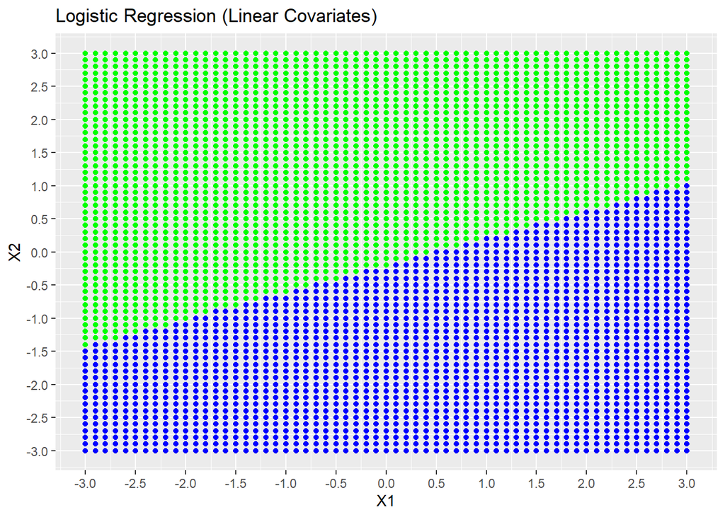

```r
logistic.linear.pred <- 1 * (predict(logistic.linear, grid, type = 'response') > 0.5)
ggplot(data = grid, aes(x = X1, y = X2, color = as.factor(logistic.linear.pred))) +
  geom_point() +
  scale_x_continuous(breaks = ticks) +
  scale_y_continuous(breaks = ticks) +
  ggtitle(label = 'Logistic Regression (Linear Covariates)') +
  scale_color_manual(values = c('green', 'blue'), guide = 'none')
```

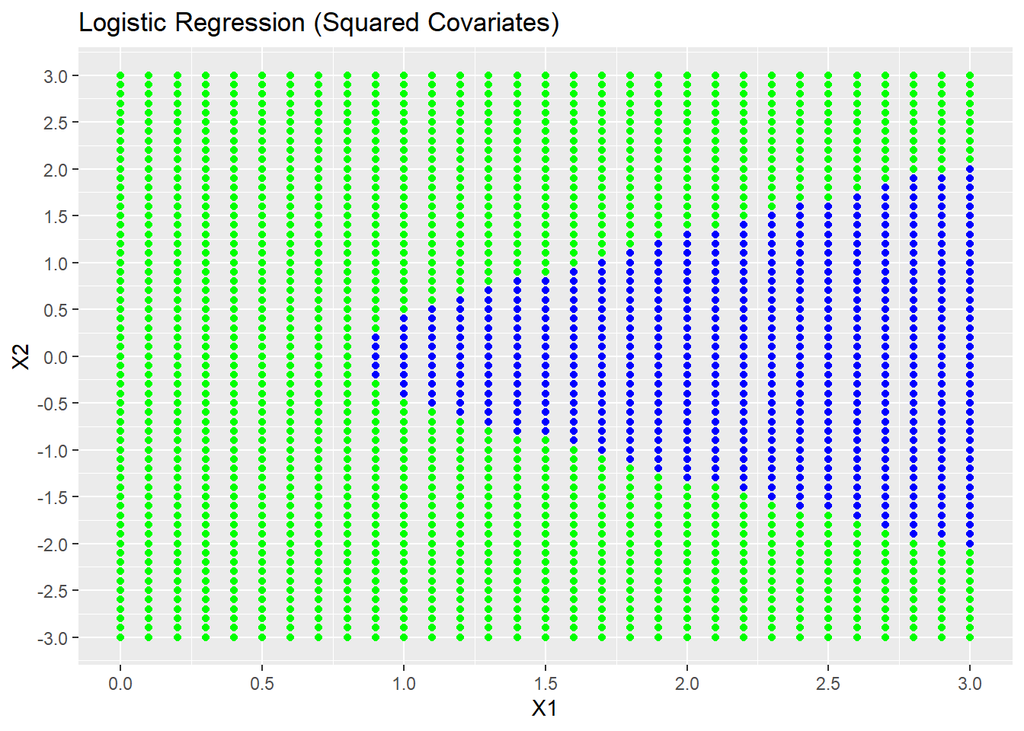

```r
grid.2 <- expand.grid(X1 = seq(0, 3, 0.1), X2 = seq(-3, 3, 0.1))
logistic.squared.pred <- 1 * (predict(glm(formula = Y ~ I(X1^2) + I(X2^2), data = prob2, family = binomial), grid.2, type = 'response') > 0.5) - 1

ggplot(data = grid.2, aes(x = X1, y = X2, color = as.factor(logistic.squared.pred))) +
  geom_point() +
  scale_x_continuous(breaks = ticks) +
  scale_y_continuous(breaks = ticks) +
  ggtitle(label = 'Logistic Regression (Squared Covariates)') +
  scale_color_manual(values = c('green', 'blue'), guide = 'none')
```

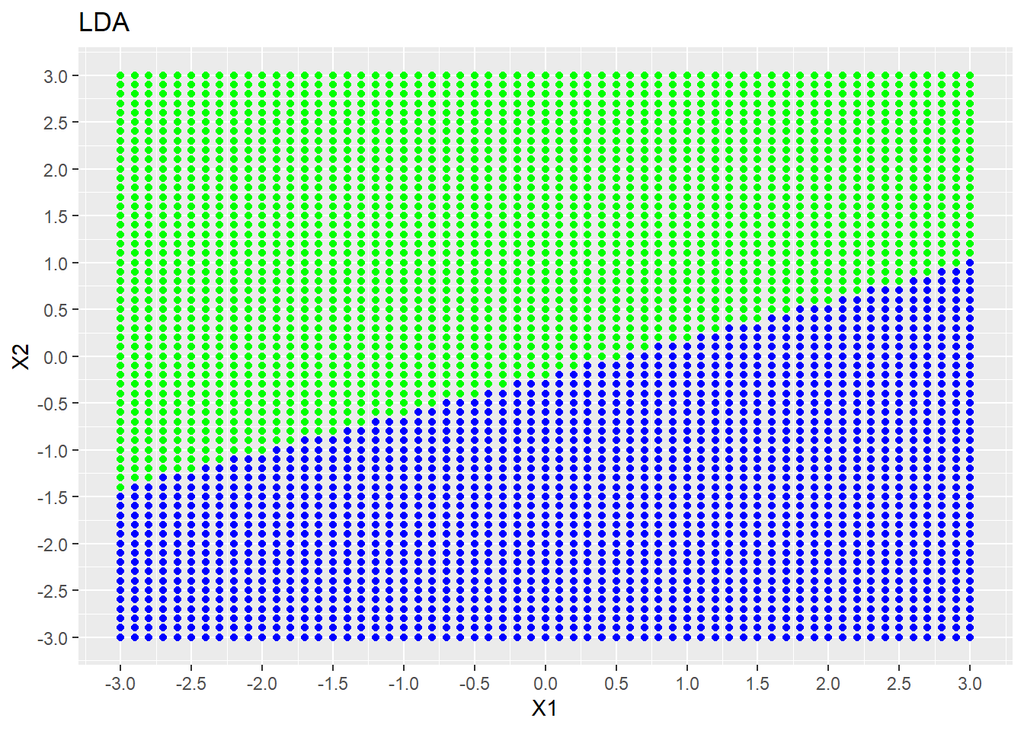

```r
lda.pred <- as.numeric(x = predict(lda.model, grid)$class) - 1
ggplot(data = grid, aes(x = X1, y = X2, color = as.factor(x = lda.pred))) +
  geom_point() +
  scale_x_continuous(breaks = ticks) +
  scale_y_continuous(breaks = ticks) +
  ggtitle(label = 'LDA') +
  scale_color_manual(values = c('green', 'blue'), guide = 'none')
```

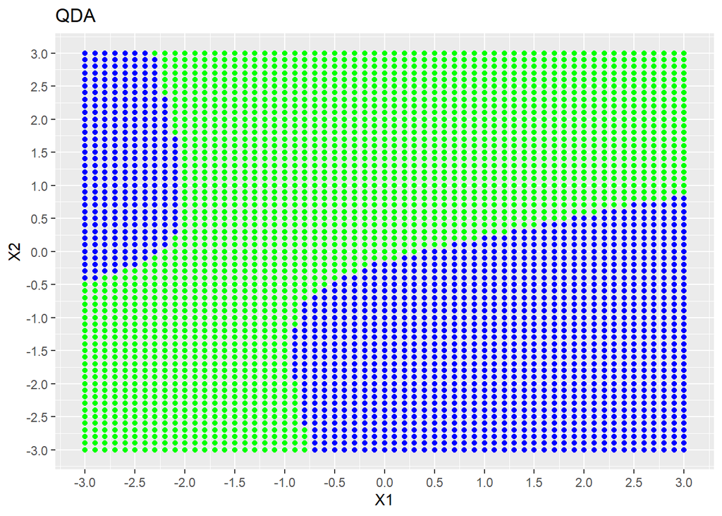

```r
qda.pred <- as.numeric(x = predict(qda.model, grid)$class)
ggplot(data = grid, aes(x = X1, y = X2, color = as.factor(qda.pred))) +
  geom_point() +
  scale_x_continuous(breaks = ticks) +
  scale_y_continuous(breaks = ticks) +
  ggtitle(label = 'QDA') +
  scale_color_manual(values = c('green', 'blue'), guide = 'none')
```

Question 2ii

The first evident observation is the use of curved boundaries by logistic regression with squared covariates and QDA. Interestingly, both the logistic regression with linear terms and LDA seem to agree on the same boundary. At this stage, it is unclear whether any model exhibits overfitting just based on visual displays. The two models that use nonlinear boundaries may be closer to overfitting than the other two models simply due to curvature of boundaries wrapping around class data points. Furthermore, QDA is prone to variance, meaning adding new data points will be very sensitive to the positioning of boundaries.

Question 2iii

```r
# load test dataset
prob2.test <- read.csv(file = 'data/Problem2test.csv')
prob2.test
```

```
##      Y           X1           X2
## 1    0  1.210146094  0.508630538
## 2    0  0.188657164  0.260949990
## 3    1  1.962498672  1.102686956
## 4    0  0.138711939 -0.023540036
## 5    0 -1.578627354 -0.076654184
## 6    0 -0.797021271  0.809930609
## 7    1  1.224353882 -1.713937928
## 8    0 -0.365333560  1.975068096
## 9    0 -0.162590280 -0.867222960
## 10   1  0.560479179  1.466811326
## 11   0 -0.860725629 -0.278560025
## 12   1  1.238634492  1.803588650
## 13   0  0.767435749  0.288172230
## 14   0 -1.087409106 -0.259131700
```

[output cut: 1486 more lines]

```r
err.rate.logistic.func <- function(model, data_test) {
  pred <- 1 * (predict(model,data_test, type = 'response') > 0.5) - 1
  ct  <- table(data_test$Y, pred)
  1 - sum(diag(prop.table(ct)))
}

err.rate.discriminant.func <- function(model, data_test) {
  pred <- as.numeric(predict(model,data_test)$class) - 1
  ct  <- table(data_test$Y, pred)
  1 - sum(diag(prop.table(ct)))
}

cat('\nError rates per model:\n')
```

```
##
## Error rates per model:
```

```r
print(err.rate.logistic.func(model = logistic.linear, data_test = prob2.test))
```

```
## [1] 0.296
```

```r
print(err.rate.logistic.func(model = glm(formula = Y ~ I(X1^2) + I(X2^2), data = prob2, family = binomial), data_test = prob2.test))
```

```
## [1] 0.4933333
```

```r
print(err.rate.discriminant.func(model = lda.model, data_test = prob2.test))
```

```
## [1] 0.2966667
```

```r
print(err.rate.discriminant.func(model = qda.model, data_test = prob2.test))
```

```
## [1] 0.3133333
```

The models ranked from lowest to highest in error rates are logistic regression w/ linear covariates, LDA, QDA, and logistic regression w/ squared covariates. The top 2 models are very close in error rate and together suggest that the two classes are quite linearly separable.

Question 3

```r
# loading data
prob3 <- read.csv(file = 'data/Problem3.csv')
prob3
```

```
##    Y          X1          X2
## 1  2  0.55432694  0.27312919
## 2  2 -0.28027194  0.75552507
## 3  0  1.77516337 -0.34901841
## 4  3  0.18732012 -0.54619076
## 5  3  1.14252615  0.23436199
## 6  1  0.41552613 -0.29782822
## 7  2  1.22950656 -0.84047613
## 8  2  0.23667967  0.82651036
## 9  0 -0.36538277  1.48369123
## 10 2  1.10514427  0.69967564
## 11 1 -1.09359397 -1.26157415
## 12 2  0.46187091  0.29827174
## 13 0 -1.36098453 -0.14780711
## 14 1 -1.85602715 -0.88892233
```

[output cut: 36 more lines]

```r
# creating models
lda.model.prob3 <- lda(formula = Y ~ X1 + X2, data = prob3)
qda.model.prob3 <- qda(formula = Y ~ X1 + X2, data = prob3)

# printing model objects
cat('\n', rep(x = '-', times = 20), '\n')
cat('\nlda.model.prob3:\n')
```

```
##
## lda.model.prob3:
```

```r
cat('\n', rep(x = '-', times = 20), '\n')
lda.model.prob3
```

```
## Call:
## lda(Y ~ X1 + X2, data = prob3)
##
## Prior probabilities of groups:
##    0    1    2    3
## 0.22 0.30 0.34 0.14
##
## Group means:
##           X1         X2
## 0 -0.3727183  0.5561256
## 1 -0.3544829 -0.1615989
## 2  0.2801608 -0.1490759
## 3  0.4762109 -0.8601008
##
## Coefficients of linear discriminants:
##           LD1       LD2
## X1  0.6624955 0.8433123
## X2 -0.9769546 0.6415818
##
## Proportion of trace:
##    LD1    LD2
## 0.8736 0.1264
```

```r
cat('\n', rep(x = '-', times = 20), '\n')
cat('\nqda.model.prob3:\n')
```

```
##
## qda.model.prob3:
```

```r
cat('\n', rep(x = '-', times = 20), '\n')
qda.model.prob3
```

```
## Call:
## qda(Y ~ X1 + X2, data = prob3)
##
## Prior probabilities of groups:
##    0    1    2    3
## 0.22 0.30 0.34 0.14
##
## Group means:
##           X1         X2
## 0 -0.3727183  0.5561256
## 1 -0.3544829 -0.1615989
## 2  0.2801608 -0.1490759
## 3  0.4762109 -0.8601008
```

Summaries of models.

```r
cat('\n', rep(x = '-', times = 20), '\n')
cat('\nLDA:\n')
```

```
##
## LDA:
```

```r
cat('\n', rep(x = '-', times = 20), '\n')
summary(object = lda.model.prob3)
```

```
##         Length Class  Mode
## prior   4      -none- numeric
## counts  4      -none- numeric
## means   8      -none- numeric
## scaling 4      -none- numeric
## lev     4      -none- character
## svd     2      -none- numeric
## N       1      -none- numeric
## call    3      -none- call
## terms   3      terms  call
## xlevels 0      -none- list
```

```r
cat('\n', rep(x = '-', times = 20), '\n')
cat('\nQDA:\n')
```

```
##
## QDA:
```

```r
cat('\n', rep(x = '-', times = 20), '\n')
summary(object = qda.model.prob3)
```

```
##         Length Class  Mode
## prior    4     -none- numeric
## counts   4     -none- numeric
## means    8     -none- numeric
## scaling 16     -none- numeric
## ldet     4     -none- numeric
## lev      4     -none- character
## N        1     -none- numeric
## call     3     -none- call
## terms    3     terms  call
## xlevels  0     -none- list
```

Question 3i.

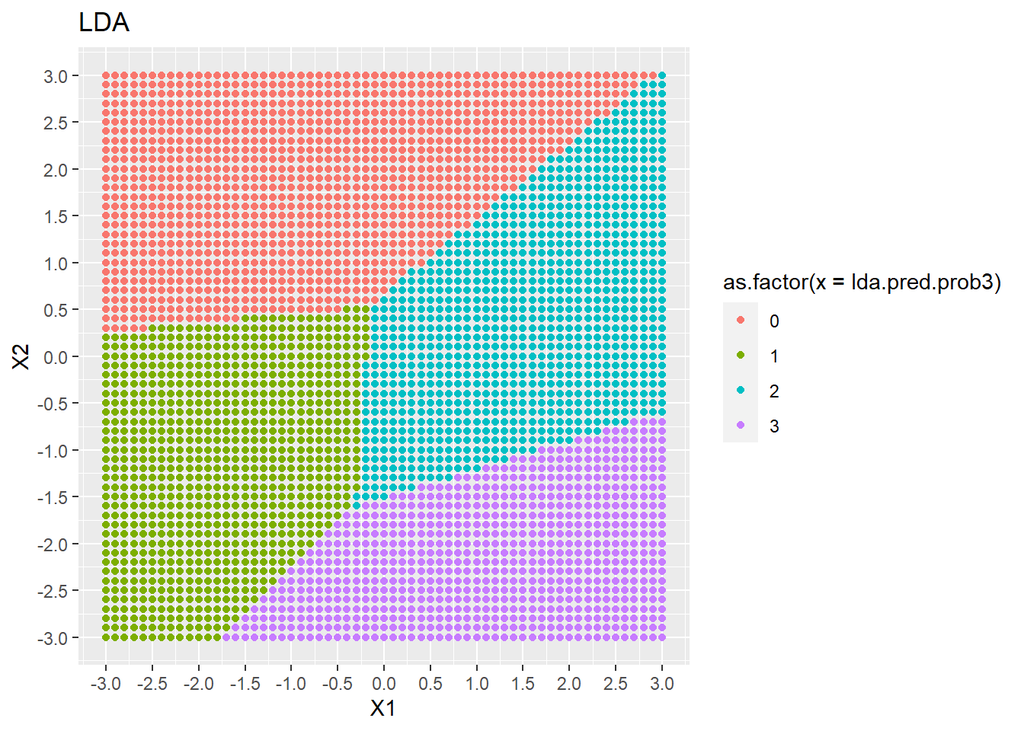

```r
lda.pred.prob3 <- as.numeric(x = predict(lda.model.prob3, grid)$class) - 1

ggplot(data = grid, aes(x = X1, y = X2, color = as.factor(x = lda.pred.prob3))) +
  geom_point() +
  scale_x_continuous(breaks = ticks) +
  scale_y_continuous(breaks = ticks) +
  ggtitle(label = 'LDA')
```

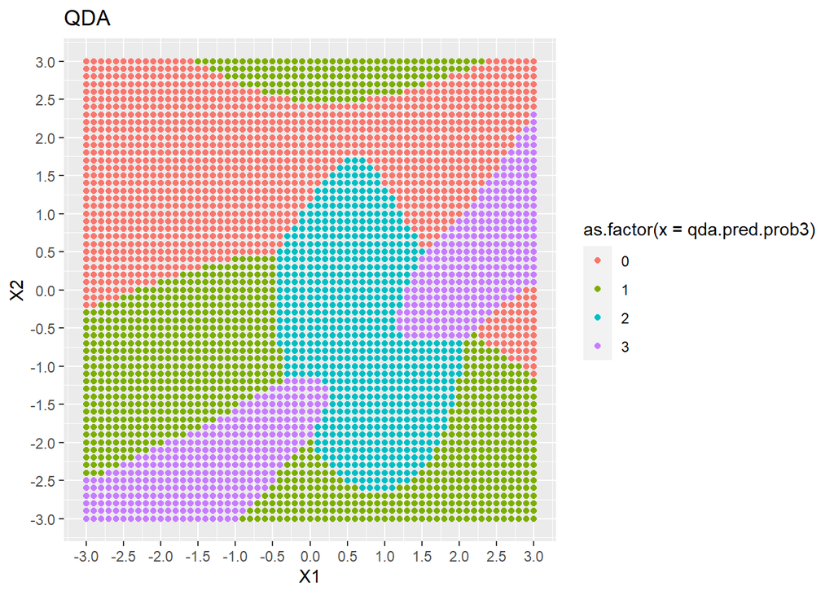

```r
qda.pred.prob3 <- as.numeric(x = predict(qda.model.prob3, grid)$class) - 1
ggplot(data = grid, aes(x = X1, y = X2, color = as.factor(x = qda.pred.prob3))) +
  geom_point() +
  scale_x_continuous(breaks = ticks) +
  scale_y_continuous(breaks = ticks) +
  ggtitle(label = 'QDA')
```

Question 3ii

```r
# load test dataset
prob3.test <- read.csv(file = 'data/Problem3test.csv')
prob3.test
```

```
##      Y           X1            X2
## 1    1  0.613784261  1.2103550739
## 2    2  0.412614524 -0.4789165684
## 3    0 -0.458893669  1.1261809006
## 4    2 -0.673178501 -1.4614845064
## 5    0  0.193054297  1.2084881405
## 6    3  1.382929057 -1.1286067035
## 7    2  0.064967339 -0.4450009431
## 8    3  2.302243701 -0.3447496159
## 9    1 -2.083677787  0.2347292455
## 10   1 -1.157149225 -0.3969460868
## 11   2  0.623805645 -1.1623811460
## 12   1 -1.522859085 -0.7384102010
## 13   0 -2.611055995  0.5251862467
## 14   3  2.526573820 -2.1093928340
```

[output cut: 1486 more lines]

LDA with 4 classes

```r
# assess the accuracy of the prediction
lda.pred.test.prob3 <- as.numeric(x = predict(lda.model.prob3, prob3.test)$class) - 1
length(x = lda.pred.test.prob3)
```

```
## [1] 1500
```

```r
# analysis
cat('\n', rep(x = '-', times = 20), '\n')
cat('\nConfusion Matrix:\n')
```

```
##
## Confusion Matrix:
```

```r
cat('\n', rep(x = '-', times = 20), '\n')
ct <- table(prob3.test$Y, lda.pred.test.prob3)
ct
```

```
##    lda.pred.test.prob3
##       0   1   2   3
##   0 149  70  36   0
##   1 128 156 193   9
##   2  30 151 282  15
##   3   4  38 166  73
```

```r
cm <- confusionMatrix(data = factor(lda.pred.test.prob3), reference = factor(prob3.test$Y))
cm
```

```
## Confusion Matrix and Statistics
##
##           Reference
## Prediction   0   1   2   3
##          0 149 128  30   4
##          1  70 156 151  38
##          2  36 193 282 166
##          3   0   9  15  73
##
## Overall Statistics
##
##                Accuracy : 0.44
##                  95% CI : (0.4147, 0.4656)
##     No Information Rate : 0.324
##     P-Value [Acc > NIR] : < 2.2e-16
##
##                   Kappa : 0.2213
##
##  Mcnemar's Test P-Value : < 2.2e-16
##
## Statistics by Class:
##
##                      Class: 0 Class: 1 Class: 2 Class: 3
## Sensitivity           0.58431   0.3210   0.5900  0.25979
## Specificity           0.86988   0.7446   0.6135  0.98031
## Pos Pred Value        0.47910   0.3759   0.4165  0.75258
## Neg Pred Value        0.91085   0.6959   0.7618  0.85175
## Prevalence            0.17000   0.3240   0.3187  0.18733
## Detection Rate        0.09933   0.1040   0.1880  0.04867
## Detection Prevalence  0.20733   0.2767   0.4513  0.06467
## Balanced Accuracy     0.72710   0.5328   0.6017  0.62005
```

```r
cat('\n', rep(x = '-', times = 20), '\n')
cat('\nDiagonal (Correct Predictions):\n')
```

```
##
## Diagonal (Correct Predictions):
```

```r
cat('\n', rep(x = '-', times = 20), '\n')
diag(prop.table(ct, 1))
```

```
##         0         1         2         3
## 0.5843137 0.3209877 0.5899582 0.2597865
```

```r
cat('\n', rep(x = '-', times = 20), '\n')
cat('\nAccuracy and Error Rate:\n')
```

```
##
## Accuracy and Error Rate:
```

```r
cat('\n', rep(x = '-', times = 20), '\n')
acc.prob3 <- sum(diag(prop.table(ct)))
err.prob3 <- 1 - sum(diag(prop.table(ct)))
acc.prob3
```

```
## [1] 0.44
```

```r
err.prob3
```

```
## [1] 0.56
```

QDA with 4 classes

```r
# assess the accuracy of the prediction
qda.pred.test.prob3 <- as.numeric(x = predict(qda.model.prob3, prob3.test)$class) - 1
length(x = qda.pred.test.prob3)
```

```
## [1] 1500
```

```r
# assess
cat('\n', rep(x = '-', times = 20), '\n')
cat('\nConfusion Matrix:\n')
```

```
##
## Confusion Matrix:
```

```r
cat('\n', rep(x = '-', times = 20), '\n')
ct <- table(prob3.test$Y, qda.pred.test.prob3)
ct
```

```
##    qda.pred.test.prob3
##       0   1   2   3
##   0 124  62  66   3
##   1 116 125 229  16
##   2  27 110 288  53
##   3  15  37 159  70
```

```r
cm.prob3 <- confusionMatrix(data = factor(qda.pred.test.prob3), reference = factor(prob3.test$Y))
cm.prob3
```

```
## Confusion Matrix and Statistics
##
##           Reference
## Prediction   0   1   2   3
##          0 124 116  27  15
##          1  62 125 110  37
##          2  66 229 288 159
##          3   3  16  53  70
##
## Overall Statistics
##
##                Accuracy : 0.4047
##                  95% CI : (0.3797, 0.43)
##     No Information Rate : 0.324
##     P-Value [Acc > NIR] : 3.298e-11
##
##                   Kappa : 0.1738
##
##  Mcnemar's Test P-Value : < 2.2e-16
##
## Statistics by Class:
##
##                      Class: 0 Class: 1 Class: 2 Class: 3
## Sensitivity           0.48627  0.25720   0.6025  0.24911
## Specificity           0.87309  0.79389   0.5558  0.94094
## Pos Pred Value        0.43972  0.37425   0.3881  0.49296
## Neg Pred Value        0.89245  0.69039   0.7493  0.84462
## Prevalence            0.17000  0.32400   0.3187  0.18733
## Detection Rate        0.08267  0.08333   0.1920  0.04667
## Detection Prevalence  0.18800  0.22267   0.4947  0.09467
## Balanced Accuracy     0.67968  0.52554   0.5791  0.59502
```

```r
cat('\n', rep(x = '-', times = 20), '\n')
cat('\nDiagonal (Correct Predictions):\n')
```

```
##
## Diagonal (Correct Predictions):
```

```r
cat('\n', rep(x = '-', times = 20), '\n')
diag(prop.table(ct, 1))
```

```
##         0         1         2         3
## 0.4862745 0.2572016 0.6025105 0.2491103
```

```r
cat('\n', rep(x = '-', times = 20), '\n')
cat('\nAccuracy and Error Rate:\n')
```

```
##
## Accuracy and Error Rate:
```

```r
cat('\n', rep(x = '-', times = 20), '\n')
acc.prob3 <- sum(diag(prop.table(ct)))
err.prob3 <- 1 - sum(diag(prop.table(ct)))
acc.prob3
```

```
## [1] 0.4046667
```

```r
err.prob3
```

```
## [1] 0.5953333
```

For both LDA and QDA, the error rates are a small margin above half (0.56 and 0.5953, correspondingly). QDA actually performed slightly less accurately than LDA. The dataset may have linearly separable classes, and/or the dataset size may be too small to alleviate noticeable effects of variance for QDA. But these points are only speculation. As expected with a higher error rate, QDA had lower sensitivity or recall for all classes except slightly better with the 3rd class when comparing to LDA via confusion matrices.

```r
# class sizes
for (class in 0:3) {
  cat('\nClass ', class, ' size: ', length(x = prob3.test[prob3.test$Y == class, ]$Y), '\n')
}
```

```
##
## Class  0  size:  255
##
## Class  1  size:  486
##
## Class  2  size:  478
##
## Class  3  size:  281
```

```r
library(dplyr)
class.size <- prob3.test %>% count(Y)
class.size$prop <- prop.table(x = class.size)$n
class.size$err <- 1 - class.size$prop
class.size
```

```
##   Y   n      prop       err
## 1 0 255 0.1693227 0.8306773
## 2 1 486 0.3227092 0.6772908
## 3 2 478 0.3173971 0.6826029
## 4 3 281 0.1865870 0.8134130
```

Question 3 iii

Simply having an error rate > 0.50 should not be immediately interpreted as being awful performance. From the cell above, each class has a much higher chance of misclassification than 0.50 based on random guessing with account of class sizes. Keep in mind that > 0.50 can be interpreted as worse than random guessing for binary cases of equal class sizes, but the problem at hand has 4 classes with no class consuming over half of all data points.

Question 3 iv

Assuming that class sizes are all equal; that is, each class holds 0.25 of all data points. By randomly guessing, there would still be a 0.75 to 0.25 odds of misclassifying as opposed to correctly classifying an instance regardless of class. With an error rate of ~60%, QDA still outperforms random guessing with equal class sizes by a substantial margin.

Question 4

Question 4i

Steps to run simulation study, with code right after.

```r
# metadata
n = 1:20 * 100 # monotonically increasing dataset size
n.sim = 100 # number of simulations (trials)
model.formula <- Y ~ exp(x = X1) + exp(x = 0.5 * X2)
model.formula.func <- 0

expit = function(x) {
  exp(x = x) / (1 + exp(x = x))
}

lda.err <- matrix(data = 0, nrow = n.sim, ncol = length(x = n))
qda.err <- matrix(data = 0, nrow = n.sim, ncol = length(x = n))

# each simulation or trial
for(i in 1:n.sim) {

  # each differently sized dataset per simulation
  for(j in 1:length(x = n)) {

    # Setup for both LDA and QDA
    # generating data
    size <- n[j] # size of dataset
    data <- data.frame(X1 = rnorm(n = size), X2 = rnorm(n = size))
    p <- expit(x = exp(data$X1) - exp(0.5 * data$X2))
    data$Y = rbinom(n = n, size = 1, p = p)

    # train test split
    train.index <- caret::createDataPartition(y = data$Y, list = FALSE)
    train.set <- data[train.index,]
    test.set <- data[-train.index,]

    # LDA
    # model and prediction
    lda.model.prob4 <- MASS::lda(formula = model.formula, data = train.set)
    lda.pred.test.prob4 <- as.numeric(x = predict(lda.model.prob4, test.set)$class) - 1
    # evaluation
    ct <- table(test.set$Y, lda.pred.test.prob4)
    acc.prob4 <- sum(diag(prop.table(ct)))
    err.prob4 <- 1 - sum(diag(prop.table(ct)))
    lda.err[i, j] <- err.prob4

    # QDA
    # model and prediction
    qda.model.prob4 <- MASS::qda(formula = model.formula, data = train.set)
    qda.pred.test.prob4 <- as.numeric(x = predict(qda.model.prob4, test.set)$class) - 1
    # evaluation
    ct <- table(test.set$Y, qda.pred.test.prob4)
    acc.prob4 <- sum(diag(prop.table(ct)))
    err.prob4 <- 1 - sum(diag(prop.table(ct)))
    qda.err[i, j] <- err.prob4
  }

}
```

```r
# verifying and averaging error rate data over all simulations
cat('\n', rep(x = '-', times = 20), '\n')
cat('\nModel error rates:\n')
```

```
##
## Model error rates:
```

```r
cat('\n', rep(x = '-', times = 20), '\n')
as.data.frame(x = lda.err)
```

```
##           V1   V2        V3    V4       V5        V6        V7     V8        V9
## 1   0.740000 0.44 0.7066667 0.640 0.676000 0.6500000 0.4628571 0.4325 0.4266667
## 2   0.600000 0.25 0.8200000 0.410 0.536000 0.4566667 0.5828571 0.6150 0.3888889
## 3   0.480000 0.54 0.4333333 0.475 0.532000 0.7033333 0.4342857 0.6900 0.6044444
## 4   0.360000 0.43 0.5933333 0.670 0.308000 0.3466667 0.6514286 0.4200 0.3333333
## 5   0.540000 0.49 0.4733333 0.385 0.472000 0.7300000 0.5942857 0.3725 0.6800000
## 6   0.755102 0.48 0.3533333 0.425 0.496000 0.2100000 0.5171429 0.4400 0.3888889
## 7   0.440000 0.38 0.4333333 0.520 0.532000 0.4633333 0.6200000 0.4350 0.4755556
## 8   0.480000 0.49 0.4133333 0.495 0.524000 0.5000000 0.4914286 0.4675 0.4600000
## 9   0.500000 0.41 0.4133333 0.415 0.448000 0.4533333 0.3600000 0.5100 0.7155556
## 10  0.420000 0.51 0.3600000 0.460 0.380000 0.5466667 0.5200000 0.3575 0.4800000
## 11  0.640000 0.46 0.3866667 0.315 0.536000 0.4966667 0.4057143 0.4050 0.5977778
## 12  0.480000 0.39 0.4266667 0.340 0.340000 0.4600000 0.5257143 0.4150 0.4800000
## 13  0.680000 0.65 0.4400000 0.525 0.280000 0.5133333 0.7507163 0.4925 0.4666667
## 14  0.460000 0.75 0.5866667 0.415 0.368000 0.5433333 0.5085714 0.5075 0.5266667
```

[output cut: 288 more lines]

```r
as.data.frame(x = qda.err)
```

```
##            V1   V2         V3    V4        V5        V6        V7     V8
## 1   0.2600000 0.55 0.36666667 0.370 0.5520000 0.6500000 0.5057143 0.5550
## 2   0.5200000 0.25 0.82000000 0.465 0.5400000 0.5333333 0.4342857 0.4700
## 3   0.6200000 0.52 0.46666667 0.470 0.5000000 0.3300000 0.4600000 0.6900
## 4   0.3800000 0.51 0.43333333 0.325 0.3200000 0.3800000 0.3600000 0.4225
## 5   0.4400000 0.46 0.45333333 0.375 0.4640000 0.7300000 0.5942857 0.3850
## 6   0.3061224 0.52 0.36666667 0.460 0.5000000 0.2300000 0.5314286 0.4325
## 7   0.4600000 0.42 0.52000000 0.520 0.4320000 0.4600000 0.4114286 0.4475
## 8   0.6000000 0.45 0.40000000 0.540 0.4680000 0.5033333 0.4800000 0.4500
## 9   0.4800000 0.43 0.39333333 0.540 0.4920000 0.4633333 0.3885714 0.5100
## 10  0.4200000 0.56 0.39333333 0.465 0.3920000 0.5066667 0.5400000 0.3625
## 11  0.5000000 0.48 0.40666667 0.580 0.5040000 0.5033333 0.4342857 0.4450
## 12  0.5600000 0.39 0.41333333 0.380 0.3960000 0.4500000 0.5114286 0.4400
## 13  0.6800000 0.47 0.54000000 0.505 0.2840000 0.4833333 0.2607450 0.5050
## 14  0.4600000 0.25 0.56666667 0.470 0.3720000 0.4933333 0.4942857 0.4950
```

[output cut: 288 more lines]

```r
cat('\n', rep(x = '-', times = 20), '\n')
cat('\nModel error rates means across dataset sizes:\n')
```

```
##
## Model error rates means across dataset sizes:
```

```r
cat('\n', rep(x = '-', times = 20), '\n')
lda.colMeans <- colMeans(x = lda.err)
qda.colMeans <- colMeans(x = qda.err)
prob4.err <- as.data.frame(x = cbind('lda.err.means' = lda.colMeans, 'qda.err.means' = qda.colMeans, 'size' = n))
prob4.err
```

```
##    lda.err.means qda.err.means size
## 1      0.4999510     0.4754612  100
## 2      0.4745000     0.4434000  200
## 3      0.4921342     0.4630027  300
## 4      0.4939000     0.4642000  400
## 5      0.4858601     0.4592006  500
## 6      0.4889667     0.4635333  600
## 7      0.5040715     0.4654435  700
## 8      0.4952750     0.4697750  800
## 9      0.5026000     0.4595897  900
## 10     0.5294000     0.4404000 1000
## 11     0.4898456     0.4364914 1100
## 12     0.5221500     0.4625333 1200
## 13     0.5166577     0.4474272 1300
## 14     0.4986429     0.4614286 1400
## 15     0.5159667     0.4446069 1500
## 16     0.4934375     0.4390750 1600
## 17     0.5057000     0.4483824 1700
## 18     0.5018111     0.4519778 1800
## 19     0.4950421     0.4504211 1900
## 20     0.4998500     0.4387400 2000
```

Question 4ii

QDA outperformed LDA by an increasing difference as the dataset size increased. QDA is more susceptible to variance than LDA. However, this is mended more and more as the amount of data points increases. For very large datasets, QDA can be preferred over LDA. LDA suffers more from bias and nonlinear truth. On the other hand, QDA relaxes the assumption of equal variances between classes and fares better at discriminating between classes that truly share nonlinear boundaries. The formula plugged into the `expit` function to generate Y includes exponential terms. This naturally gives edge to QDA, which can create curved boundaries to accomodate nonlinearity from the formula.

Question 4iii

Please refer to dataframe generated by `prob4.err` in the most recent cell to compare QDA and LDA error rates side by side along increasing dataset size.

Question 4iv

As dataset size increases, QDA performs with increasing accuracy (or decreasing error rate) relative to LDA. Having more data points also makes QDA less susceptible to new data points added, noting that variance is its weakness. A plot of error rates for both LDA and QDA can illustrate this trend.

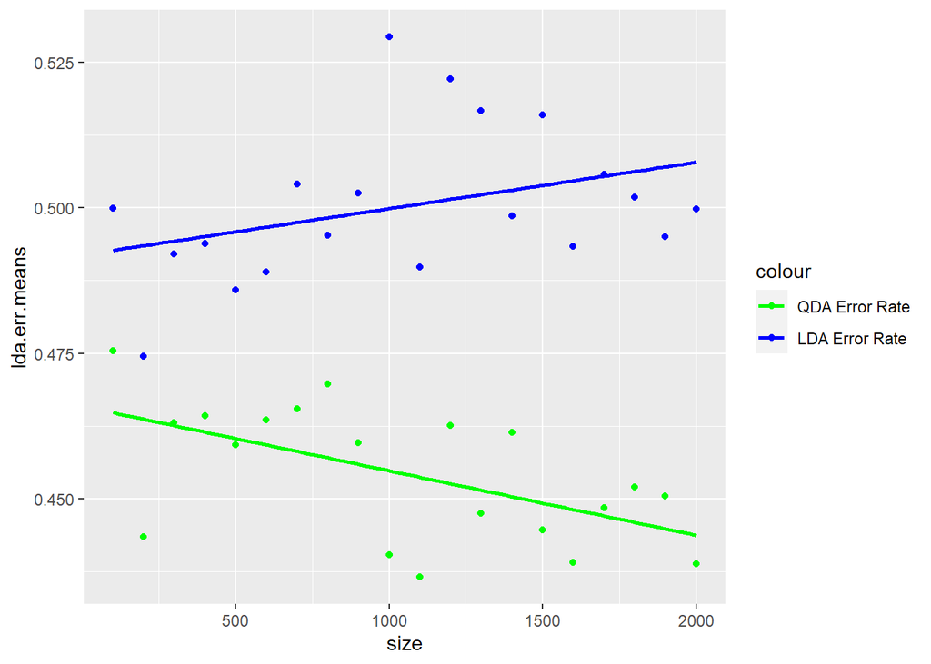

```r
ggplot(data = prob4.err, aes(x = size)) +
  geom_point(aes(y = lda.err.means, color = 'green')) +
  geom_point(aes(y = qda.err.means, color = 'blue')) +
  geom_smooth(
    method = lm,
    se = FALSE,
    fullrange = TRUE,
    aes(y = lda.err.means, color = 'green')) +
  geom_smooth(
    method = lm,
    se = FALSE,
    fullrange = TRUE,
    aes(y = qda.err.means, color = 'blue')) +
  scale_color_manual(labels = c('QDA Error Rate', 'LDA Error Rate'), values = c('green', 'blue'))
```